# HW 04 - Data Types and Classes w. forcats & lubridate

# Learning goals

- Learn how to identify and distinguish different R object classes
- Practice creating and manipulating different R object classes
- Practice manipulating factor data with forcats and dates with lubridate

# Getting started

If you’re looking at these instructions you’ve already done the following steps, but as a reminder:

- Go to the course GitHub organization and locate your Unit 3 repo, which should be named `unit-4-YOUR_LAST_NAME`.
- Grab the URL of the repo, and clone it in RStudio.
- First, open the R Markdown instructions `hw-O4-classes-forcats` and the lab starter `hw-04.Rmd` and Knit them
- Make sure they compile without errors.

## Data

We will mostly use objects that we create ourselves, as well as some use of the `earthquakes` dataset from the `{openintro}` package we have used before. We will also need `{tidyverse}` for some `{forcats}` and `{lubridate}` functions. Finally, we will need `{glue}` to help us create dates from separate columns. We will need to load the latter separately because, unlike `forcats` it is not automatically loaded with the tidyverse.

## Packages

```r
library(openintro)
library(tidyverse)
library(lubridate)
library(glue)
```

## Warm up

Before we introduce the data, let’s warm up with some simple exercises.

- Update the YAML, changing the author name to your name, and **knit** the document.
- Commit your changes with a meaningful commit message.
- Push your changes to GitHub.
- Go to your repo on GitHub and confirm that your changes are visible in your Rmd **and** md files. If anything is missing, commit and push again.

## Data classes exercises (vector, data frames, lists)

## Create some vectors

1. Insert a code chunk in your starter file under Exercise 1. Use the concatenate function `c()` to create three separate vectors, each containing five elements (i.e. length = 5). The vectors can include anything you want but make sure one is all numeric, one is all character, and one is a mix of character and numeric. Assign each vector to the following vector object names: `numeric`, `character`, `mixed`. Remember to label your code chunk. **Lastly**, using in-line code beneath your code chunk, report the `typeof()` and `class()` of each vector.

🧶 ✅ ⬆️ Knit, *commit, and push your changes to GitHub with an appropriate commit message.*

## Bind the vectors into a data frame

2. Copy the code chunk below into your starter file under Exercise 2 and complete it. The first line uses the function `bind_cols()` - which is probably new to you - to bind the vectors together as columns in a data frame and assign the data frame to the object `data_frame`. *Note that within `bind_cols()` the vectors are assigned to new variable names using `=`.* Complete the second line that will ensure our renamed data frame is output in the .html file - so that you can inspect it. Don’t forget to label the code chunk and change `eval` = T. **Lastly**, using in-line code beneath your code chunk, report the`typeof()` and `class()` of the data frame.

```r
___ <- bind_cols("numeric" = numeric, "___" = character, "___" = ___)
___
```

🧶 ✅ ⬆️ Knit, *commit, and push your changes to GitHub with an appropriate commit message.*

3. Insert a code chunk in your starter file under Exercise 3. Use the concatenate function to create three separate vectors of the same type as before. This time, two vectors should contain 5 elements, but **one vector should only contain 4 elements.** Again, assign each vector to object names: `numeric`, `character`, `mixed`. In a final lines of code, try to use `bind_cols()` again to bind the three new vectors. Why does this not work? Answer this question question in text narrative beneath your chunk. Finally, because your Rmd file will not knit if you have erroneous code, either comment out the problematic line using `#` or set eval = F in the code chunk header.

🧶 ✅ ⬆️ Knit, *commit, and push your changes to GitHub with an appropriate commit message.*

4. Copy the code chunk below into Exercise 4 in your starter file, and complete it to create a list from the same three vectors created in Exercise 3. Write in narrative beneath the chunk what this function does and why it works.

```r
___ <- list("___" = numeric, "___" = character, "mixed" = ___)
my_list
```

🧶 ✅ ⬆️ Knit, *commit, and push your changes to GitHub with an appropriate commit message.*

## `forcats` exercises (factors)

[figure not shown]

forcats is automatically loaded as part of the tidyverse

5. Copy the code chunk `earthquake-factors` into your Starter file under Exercise 5. Run the code. Under the code chunk, write a narrative response including three points: 1) What kind of data type coercion is happening to the variable `month` when it is passed to the `ggplot()` function?; 2) What is wrong/weird with the resulting visualization and why?

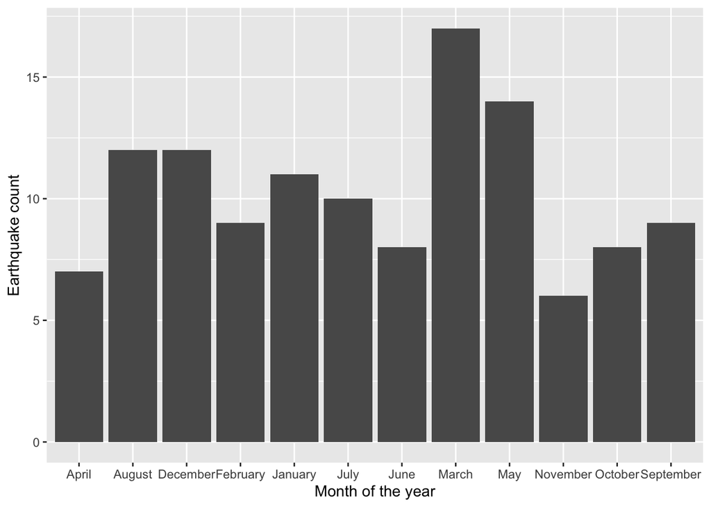

```r
earthquakes %>%
  ggplot(aes(x = month)) +
  geom_bar() +
  labs(x = "Month of the year", y = "Earthquake count")
```

🧶 ✅ ⬆️ Knit, *commit, and push your changes to GitHub with an appropriate commit message.*

In exercise 6 we will demo using a few of the *many* `forcats` functions for manipulating factors. The R for Data Science chapter on Factors and the `?forcats` help page contains explanations on other functions. Use the following code chunks as additional reference if you’re working with factors in the future.

6. Beneath each of the following code chunks, write a sentence stating which `forcats` function is being used and what effect it has on the the variable month and the resulting ggplot visualization, including any problems with the plot. Remember you can use help pages for functions too.

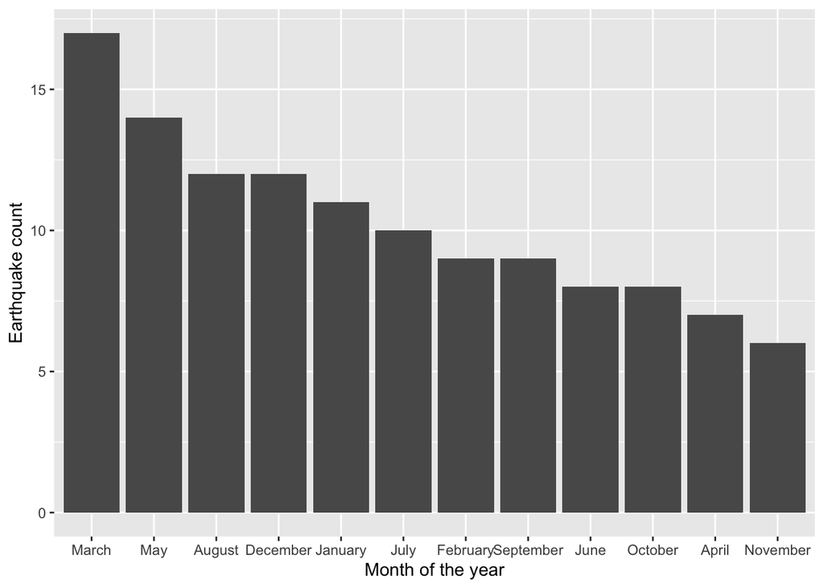

```r
earthquakes %>%
  ggplot(aes(x = fct_infreq(month))) +
  geom_bar() +
  labs(x = "Month of the year", y = "Earthquake count")
```

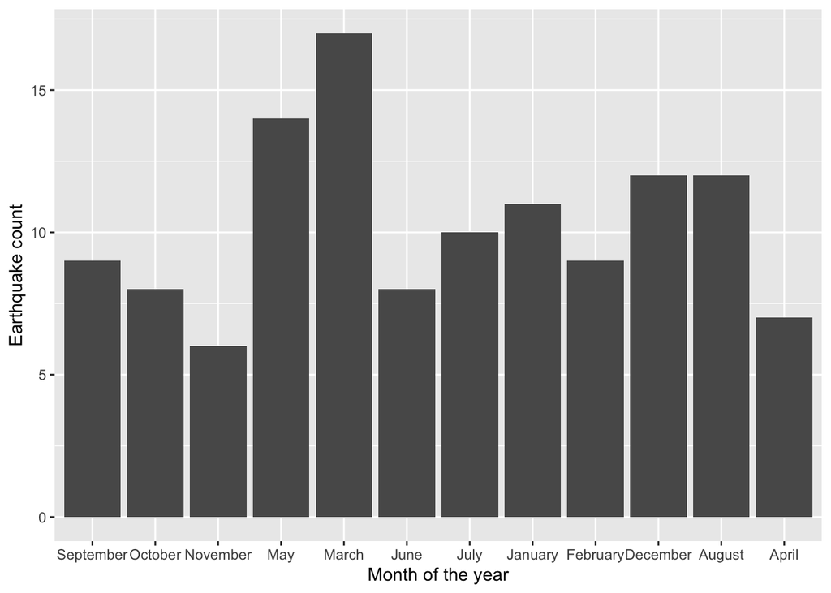

```r
earthquakes %>%
  ggplot(aes(x = fct_rev(month))) +
  geom_bar() +
  labs(x = "Month of the year", y = "Earthquake count")
```

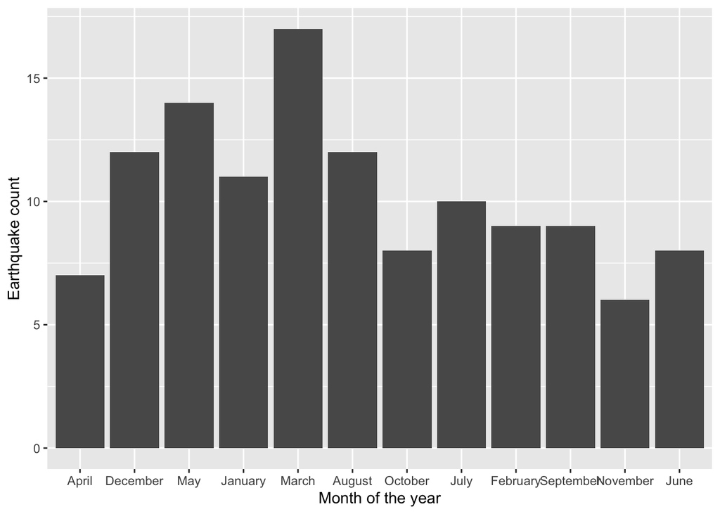

```r
earthquakes %>%
  ggplot(aes(x = fct_inorder(month))) +
  geom_bar() +
  labs(x = "Month of the year", y = "Earthquake count")
```

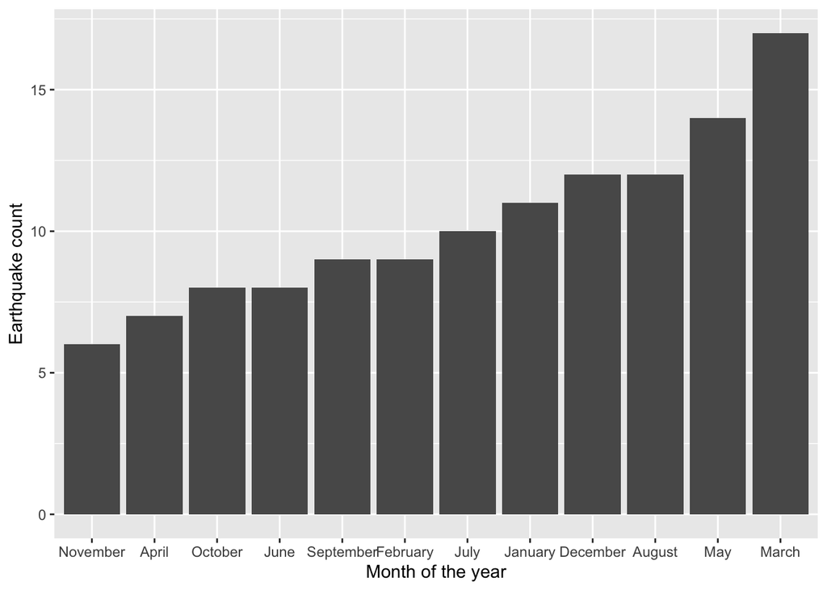

```r
earthquakes %>%
  ggplot(aes(x = month %>% fct_infreq() %>% fct_rev())) +
  geom_bar() +
  labs(x = "Month of the year", y = "Earthquake count")
```

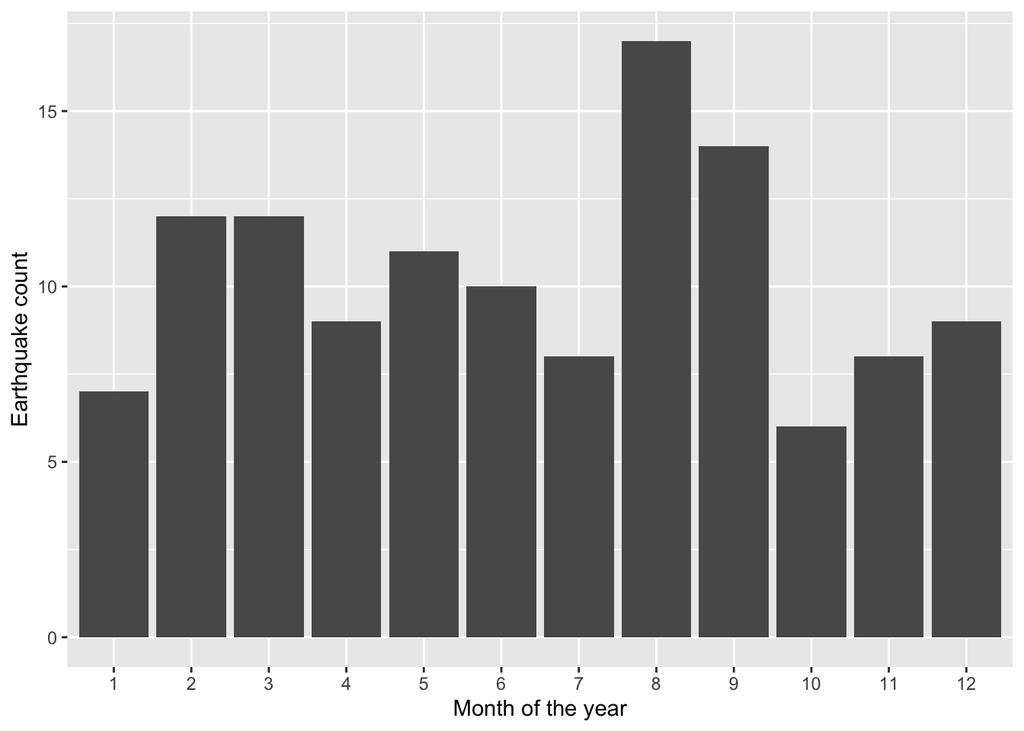

```r
earthquakes %>%
  mutate(month = fct_recode(month,
                            "1" = "January",
                            "2" = "February",
                            "3" = "March",
                            "4" = "April",
                            "5" = "May",
                            "6" = "June",
                            "7" = "July",
                            "8" = "August",
                            "9" = "September",
                            "10" = "October",
                            "11" = "November",
                            "12" = "December")) %>%
  ggplot(aes(x = factor(as.numeric(month)))) +
  geom_bar() +
  labs(x = "Month of the year", y = "Earthquake count")
```

🧶 ✅ ⬆️ Knit, *commit, and push your changes to GitHub with an appropriate commit message.*

## `lubridate` exercises (dates)

[figure not shown]

lubridate needs to be loaded separately, but is also part of the tidyverse

7. Copy the code chunk below into Exercise 7 in your starter file, and run it. Write narrative below the chunk explaining what the second and third line of this code chunk does *and* include some inline code to state what the data type and class of the new variable `date` is.

```r
earthquakes_new <- earthquakes %>%
  mutate(date = glue("{year} {month} {day}")) %>%
  relocate(date)
print(earthquakes_new)
```

```
## # A tibble: 123 × 8
##    date              year month      day richter area            region   deaths
##    <glue>           <dbl> <chr>    <dbl>   <dbl> <chr>           <chr>     <dbl>
##  1 1902 April 19     1902 April       19     7.5 Quezaltenango … Guatema…   2000
##  2 1902 December 16  1902 December    16     6.4 Uzbekistan      Russia     4700
##  3 1903 April 28     1903 April       28     7   Malazgirt       Turkey     3500
##  4 1903 May 28       1903 May         28     5.8 Gole            Turkey     1000
##  5 1905 April 4      1905 April        4     7.5 Kangra          India     19000
##  6 1906 January 31   1906 January     31     8.8 Esmeraldas (of… Ecuador    1000
##  7 1906 March 16     1906 March       16     6.8 Chia-i          Taiwan     1250
##  8 1906 April 18     1906 April       18     7.7 San Francisco   United …   3000
##  9 1906 August 17    1906 August      17     8.6 Valparaiso      Chile      3882
## 10 1907 October 21   1907 October     21     8.1 Central         Asia      12000
## # … with 113 more rows
```

🧶 ✅ ⬆️ Knit, *commit, and push your changes to GitHub with an appropriate commit message.*

8. Create and label a new code chunk under exercise 8. In the code chunk, pipe `earthquakes_new` into a filter function that selects only the year 1933, then pipe the filtered data into ggplot and map the `date` variable to the x-axis and `richter` to the y-axis. Visualize using a scatter plot. Write text narrative beneath your chunk stating what is wrong with this plot, and why.

🧶 ✅ ⬆️ Knit, *commit, and push your changes to GitHub with an appropriate commit message.*

9. Copy and the code chunk below into exercise 9 and complete it. You need to add a function from the `lubridate` package that will convert the `date` variable from class `character` to class `date`. Hint: we covered this in the lecture slides on Wednesday 10/13. Remember to change eval = T to have the code execute when you knit your starter document.

```r
earthquakes %>%
  mutate(date = ___(glue("{year} {month} {day}"))) %>%
  relocate(date) %>%
  ggplot(aes(x = date, y = richter)) +
  geom_point()
```

Great work! You are finished with Homework 4! 🧶 ✅ ⬆️ Knit, *commit, and push your changes to GitHub with an appropriate commit message.*